# craywatch: fc trend evaluation

2025-10-24

# Laad packages

```r
library(here)
library(dplyr)
```

```r
library(ggplot2)
library(corrplot)
library(DHARMa)
library(glmmTMB)
library(tidyr)
library(ggbeeswarm)
library(TOSTER)
library(wrappedtools)
```

# Laad data

```r
data_fc_cray_notAvg <- read.table(file=here("data","intermediate","data_fc_cray_notAvg.txt"),header=T)

data_fc_cray_notAvg_zomer <- read.table(file=here("data","intermediate","data_fc_cray_notAvg_summer.txt"),header=T)
```

# Algemene trend in FC data

## Visualiseer trend van enkele locaties

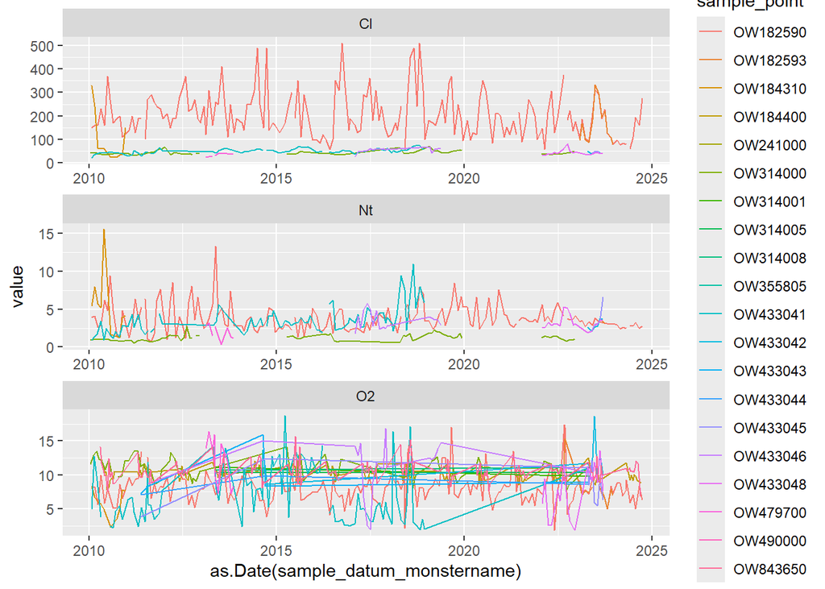

```r
data_fc_cray_notAvg%>%
  pivot_longer(cols=O2:Clfyl.a)%>%
  dplyr::filter(name%in%c("Cl","Nt","O2"), sample_point%in%unique(sample_point)[1:20])%>%
ggplot(aes(x=as.Date(sample_datum_monstername), y=value, group_by=sample_point, col=sample_point))+geom_line()+facet_wrap(~name, scales="free",ncol=1)
```

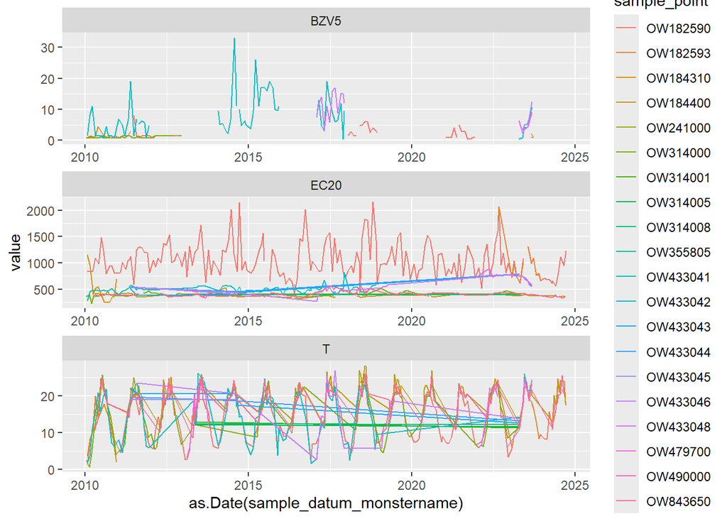

```r
data_fc_cray_notAvg%>%
  pivot_longer(cols=O2:Clfyl.a)%>%
  dplyr::filter(name%in%c("BZV5","EC20","T"),  sample_point%in%unique(sample_point)[1:20])%>%
ggplot(aes(x=as.Date(sample_datum_monstername), y=value, group_by=sample_point, col=sample_point))+geom_line()+facet_wrap(~name, scales="free",ncol=1)
```

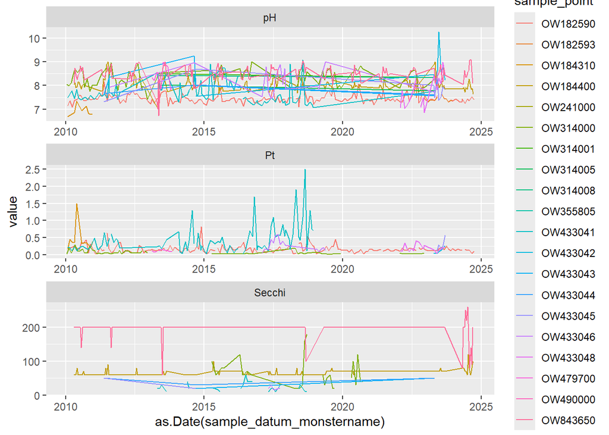

```r
data_fc_cray_notAvg%>%
  pivot_longer(cols=O2:Clfyl.a)%>%
  dplyr::filter(name%in%c("pH","Secchi","Pt"),  sample_point%in%unique(sample_point)[1:20])%>%
ggplot(aes(x=as.Date(sample_datum_monstername), y=value, group_by=sample_point, col=sample_point))+geom_line()+facet_wrap(~name, scales="free",ncol=1)
```

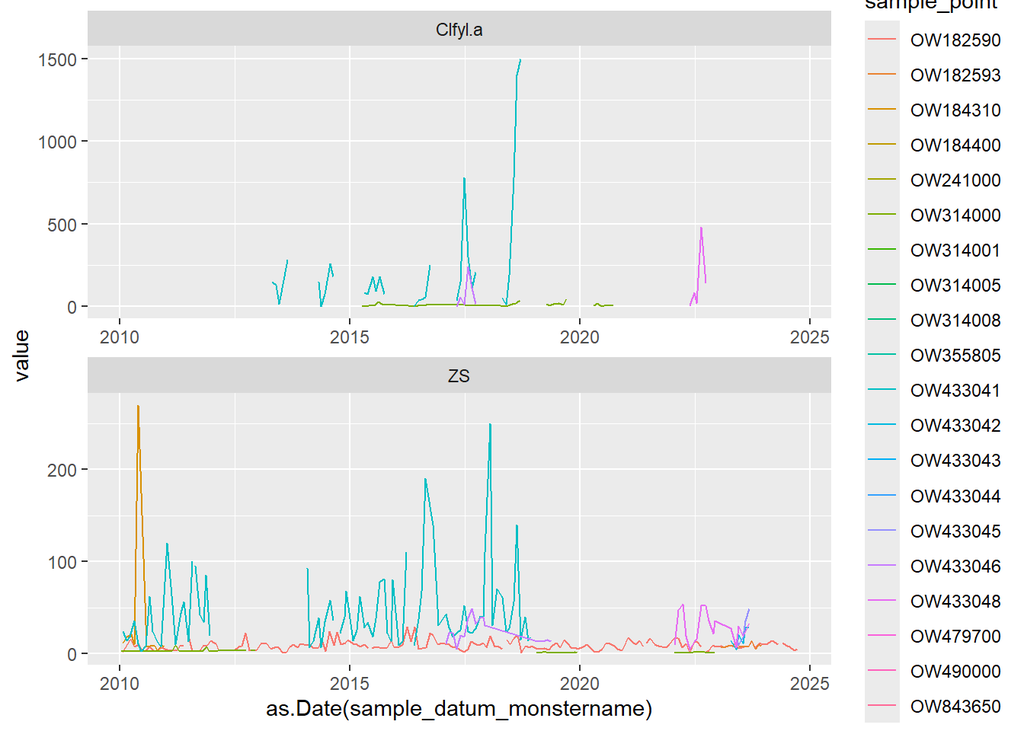

```r
data_fc_cray_notAvg%>%
  pivot_longer(cols=O2:Clfyl.a)%>%
  dplyr::filter(name%in%c("Cao","Clfyl.a","ZS"),  sample_point%in%unique(sample_point)[1:20])%>%
ggplot(aes(x=as.Date(sample_datum_monstername), y=value, group_by=sample_point, col=sample_point))+geom_line()+facet_wrap(~name, scales="free",ncol=1)
```

## Visualiseer trend van enkel zomer maanden

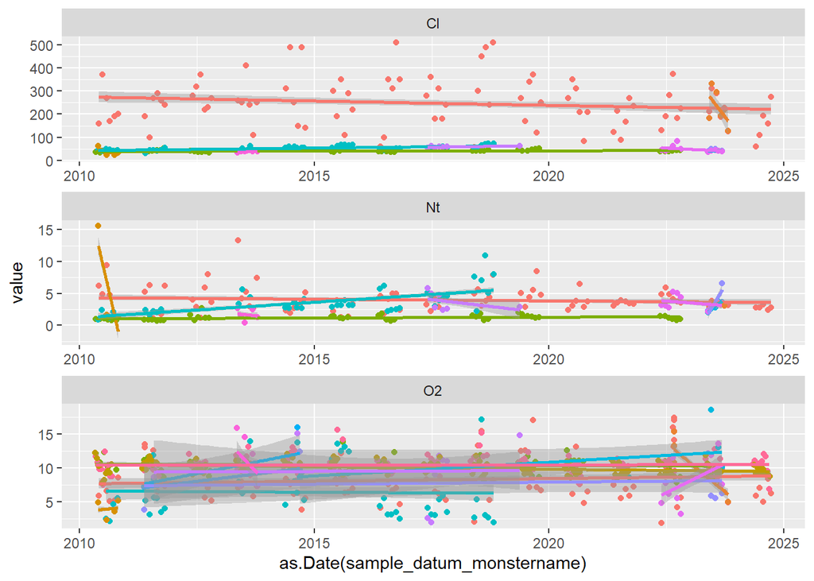

```r
data_fc_cray_notAvg%>%
  pivot_longer(cols=O2:Clfyl.a)%>%
  dplyr::filter(name%in%c("Cl","Nt","O2"), sample_point%in%unique(sample_point)[1:20],
                 MaandNr%in%5:10)%>%
  ungroup()%>%
ggplot(aes(x=as.Date(sample_datum_monstername), y=value, group_by=sample_point, col=sample_point))+geom_point()+facet_wrap(~name, scales="free",ncol=1)+stat_smooth(method="lm")+guides(colour="none")
```

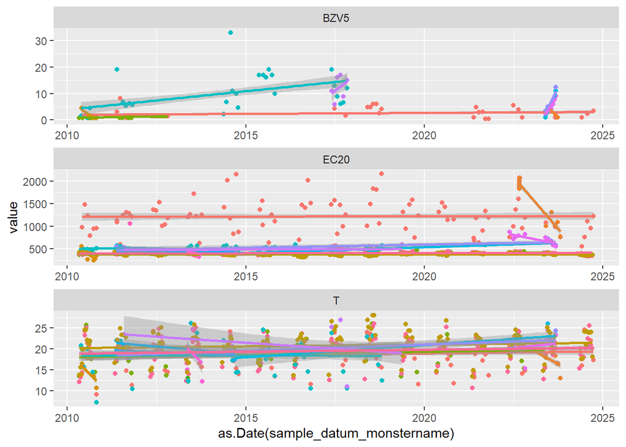

```r
data_fc_cray_notAvg%>%
  pivot_longer(cols=O2:Clfyl.a)%>%
  dplyr::filter(name%in%c("BZV5","EC20","T"),  sample_point%in%unique(sample_point)[1:20],
                 MaandNr%in%5:10)%>%
  ungroup()%>%
ggplot(aes(x=as.Date(sample_datum_monstername), y=value, group_by=sample_point, col=sample_point))+geom_point()+facet_wrap(~name, scales="free",ncol=1)+stat_smooth(method="lm")+guides(colour="none")
```

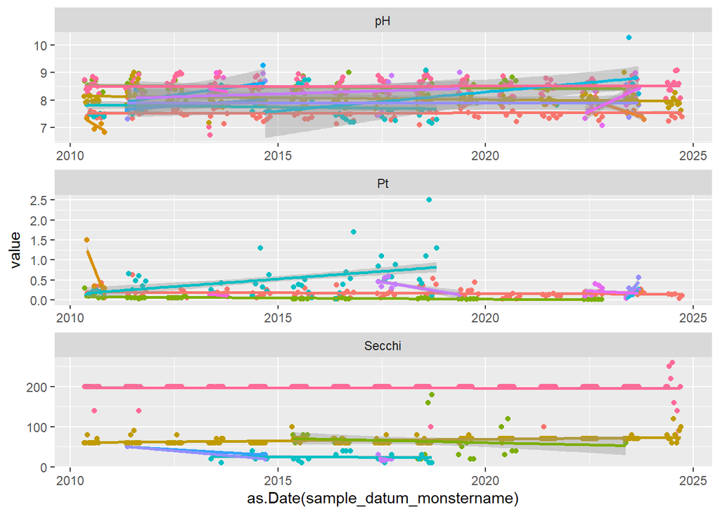

```r
data_fc_cray_notAvg%>%
  pivot_longer(O2:Clfyl.a)%>%
  dplyr::filter(name%in%c("pH","Secchi","Pt"),  sample_point%in%unique(sample_point)[1:20],
                 MaandNr%in%5:10)%>%
  ungroup()%>%
ggplot(aes(x=as.Date(sample_datum_monstername), y=value, group_by=sample_point, col=sample_point))+geom_point()+facet_wrap(~name, scales="free",ncol=1)+stat_smooth(method="lm")+guides(colour="none")
```

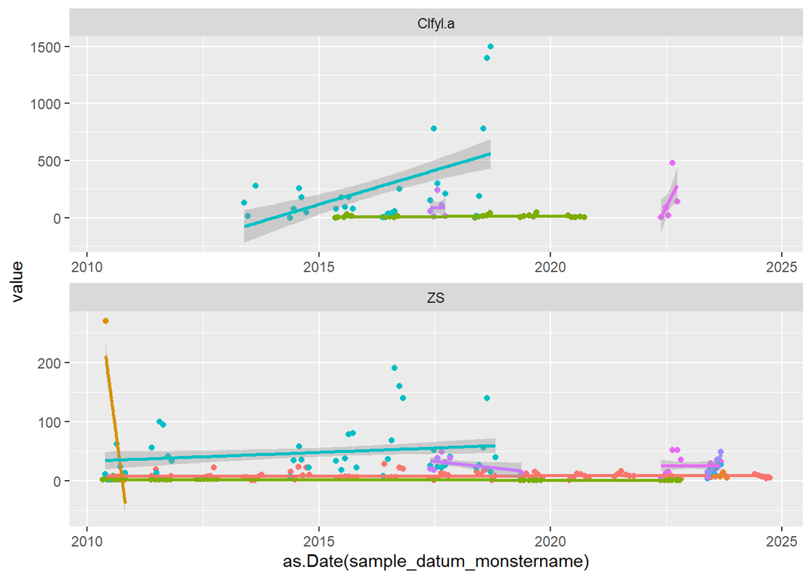

```r
data_fc_cray_notAvg%>%
  pivot_longer(cols=O2:Clfyl.a)%>%
  dplyr::filter(name%in%c("Cao","Clfyl.a","ZS","ZS"),  sample_point%in%unique(sample_point)[1:20],
 MaandNr%in%5:10)%>%
  ungroup()%>%
ggplot(aes(x=as.Date(sample_datum_monstername), y=value, group_by=sample_point, col=sample_point))+geom_point()+facet_wrap(~name, scales="free",ncol=1)+stat_smooth(method="lm")+guides(colour="none")
```

# Visualiseer distributies ruwe data en relatieve waarden

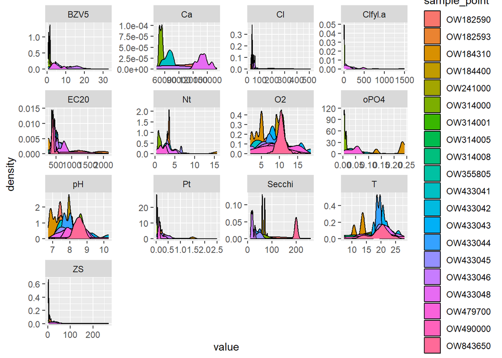

```r
data_fc_cray_notAvg%>%
  pivot_longer(cols=O2:Clfyl.a)%>%
    dplyr::filter( MaandNr%in%5:10, sample_point%in%unique(sample_point)[1:20])%>%
  ggplot(aes(x=value, group_by=sample_point, fill=sample_point))+geom_density()+
  facet_wrap(~name, scales="free")
```

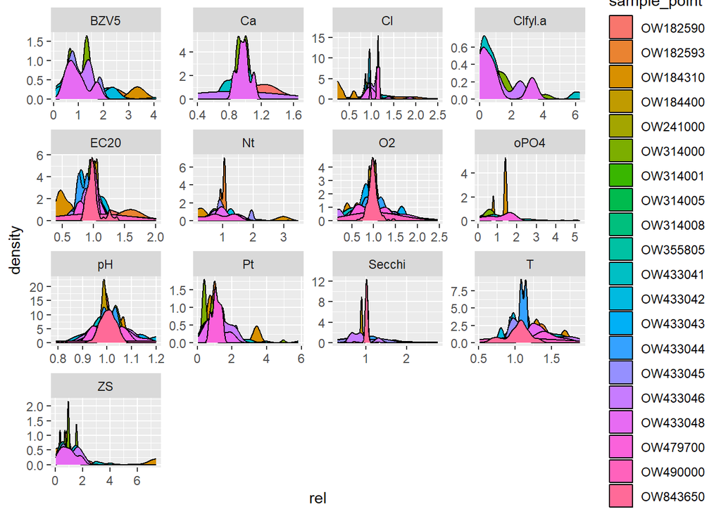

```r
data_fc_cray_notAvg%>%
  pivot_longer(cols=O2:Clfyl.a)%>%
  group_by(sample_point, name)%>%
  mutate(meanval=mean(value,na.rm=TRUE),
         rel=value/meanval)%>%
  ungroup()%>%
    dplyr::filter( MaandNr%in%5:10, sample_point%in%unique(sample_point)[1:20])%>%
  ggplot(aes(x=rel, group_by=sample_point, fill=sample_point))+geom_density()+
  facet_wrap(~name, scales="free")+guides(colour="none")
```

# Bepaal thresholds

Om de thresholds voor de equivalence test te bepalen is beslist om de standaard error (SE) rond de mediaan te gebruiken. De SE geeft een maat voor de dispersie van de sample mediaan rond de populatie mediaan. De data zijn skewed zelfs als we naar relatieve waarden kijken, daarom is voor de mediaan en niet gemiddelde gekozen . Mediaan is immers minder gevoelig aan extreme observaties dan het gemiddelde. Er is getest op de ruwe waarden omdat die meer overeenkomen met de waarden die we gebruiken voor de analyse, en niet op de relatieve data. Door de SE te gebruiken kan de thresholds aangepast worden aan de variatie die in een specifieke variabele zit in plaats van 1 algemene threshold.

## Bereken standaard error rond mediaan per variabele van de ruwe data

```r
data_fc_cray_notAvg%>%
  pivot_longer(cols=O2:Clfyl.a)%>%
   distinct(sample_point,
           name,
           sample_datum_monstername,
           sample_tijdstip_monstername,.keep_all = T)%>%
    dplyr::filter( MaandNr%in%5:10,!is.na(value))%>%
  group_by(name)%>%
  summarise(Median=median(value,na.rm=TRUE),
            MAD=mad(value,na.rm=TRUE),
            MedianSE=medianse(value))
```

```
## # A tibble: 13 × 4
##    name      Median       MAD  MedianSE
##    <chr>      <dbl>     <dbl>     <dbl>
##  1 BZV5        2        1.48    0.0183
##  2 Ca      84000    50408.    878.
##  3 Cl         66       47.4     0.460
##  4 Clfyl.a    31       39.5     1.18
##  5 EC20      549      351.      2.45
##  6 Nt          3.3      2.13    0.0208
##  7 O2          8.46     2.49    0.0173
##  8 Pt          0.37     0.311   0.00303
##  9 Secchi     80       29.7     0.298
## 10 T          18.6      3.85    0.0267
## 11 ZS         10        9.04    0.0901
## 12 oPO4        0.2      0.237   0.00318
## 13 pH          7.87     0.593   0.00413
```

Wanneer de algemene SE gebruikt wordt, wordt niet in rekening gebracht dat sommige locaties hogere waarden hebben dan andere. Dit kan de SE verhogen terwijl de variatie binnen een locatie eigenlijk niet zo hoog is. Daarom werd de SE per locatie berekend en worden deze waarden gebruikt om de threshold te bepalen.

## Bereken standaard error rond mediaan per locatie en variabele van de ruwe data

```r
median_se <- data_fc_cray_notAvg%>%
  pivot_longer(cols=O2:Clfyl.a)%>%
   distinct(sample_point,
           name,
           sample_datum_monstername,
           sample_tijdstip_monstername,.keep_all = T)%>%
    dplyr::filter( MaandNr%in%5:10,!is.na(value))%>%
  group_by(name,sample_point)%>%
  dplyr::filter(n()>10)%>%
  summarise(Median=median(value,na.rm=TRUE),
            MAD=mad(value,na.rm=TRUE),
            MedianSE=medianse(value))
```

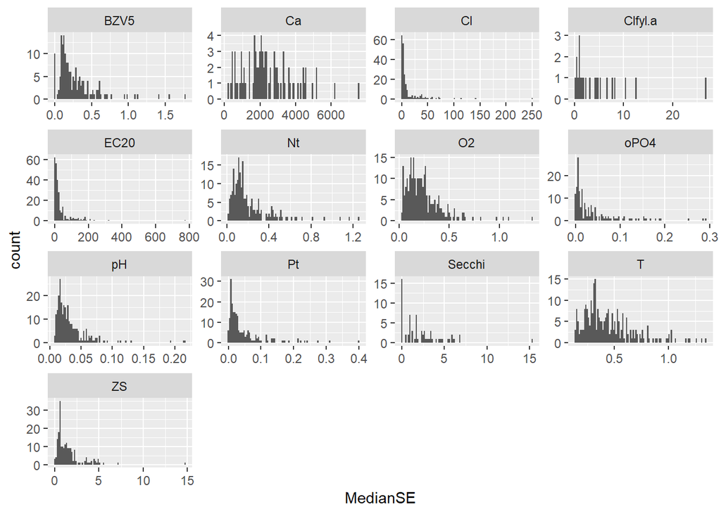

```r
ggplot(median_se,aes(x=MedianSE))+geom_histogram(bins=100)+facet_wrap(~name, scales="free")
```

De standaard errors van de verschillende locaties zijn ook skewed, daarom is het beter de mediaan van de SE in plaats van de gemiddelde SE per locatie te gebruiken.

## Bepaal de threshold

```r
median_se%>%
  group_by(name)%>%
    do(data.frame(t(quantile(.$MedianSE))))
```

```
## # A tibble: 13 × 6
## # Groups:   name [13]
##    name          X0.       X25.      X50.      X75.    X100.
##    <chr>       <dbl>      <dbl>     <dbl>     <dbl>    <dbl>
##  1 BZV5      0          0.113      0.186     0.353     1.77
##  2 Ca      216.      1586.      2117.     3191.     7551.
##  3 Cl        0.278      1.25       3.16      8.30    250.
##  4 Clfyl.a   0.198      1.01       2.78      6.38     26.8
##  5 EC20      0.253      4.80      14.0      35.8     775.
##  6 Nt        0.0124     0.0935     0.145     0.256     1.25
##  7 O2        0.0296     0.125      0.206     0.309     1.33
##  8 Pt        0          0.0110     0.0244    0.0552    0.399
##  9 Secchi    0          0.468      1.75      3.34     15.3
## 10 T         0.138      0.283      0.378     0.540     1.35
## 11 ZS        0          0.578      1.02      1.81     14.7
## 12 oPO4      0          0.00572    0.0159    0.0452    0.291
## 13 pH        0.00790    0.0165     0.0249    0.0395    0.216
```

```r
thresh <- median_se%>%
  group_by(name)%>%
  summarise(thresh=median(MedianSE))
```

# Test het verschil in mediaan

De mediaan wordt gebruikt in plaats van het gemiddelde omdat de data vaak skewed zijn met enkele extreme observaties. Mediaan is minder gevoelig voor deze extreme waarden. De finale dataset zal dus ook de mediaan van de 3 jaar in plaats van het gemiddelde bevatten.

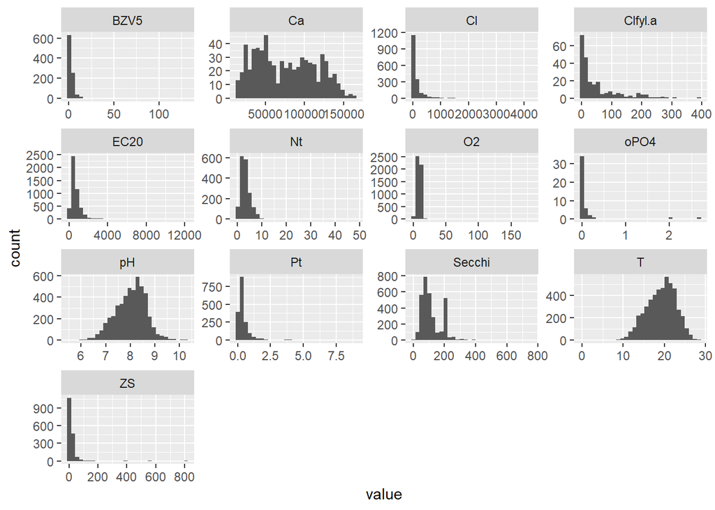

```r
data_fc_cray_notAvg_zomer_long <- data_fc_cray_notAvg_zomer%>%
  pivot_longer(cols=O2:Clfyl.a)%>%
   distinct(sample_point,
           name,
           sample_datum_monstername,
           sample_tijdstip_monstername,.keep_all = T)%>%
    dplyr::filter( MaandNr%in%5:10,!is.na(value))


ggplot(data_fc_cray_notAvg_zomer_long,aes(x=value))+geom_histogram()+facet_wrap(~name,scales="free")
```

## Bereken verschil mediaan.

```r
median_total <- data_fc_cray_notAvg_zomer_long%>%
  mutate(yearVMM=format(as.Date(sample_datum_monstername),"%Y"))%>%
  group_by(vangstID,name,sample_point)%>%
  dplyr::filter(length(unique(yearVMM))>1)%>%
  summarise(median_all=median(value,na.rm=TRUE))
median_year <- data_fc_cray_notAvg_zomer_long%>%
mutate(yearVMM=format(as.Date(sample_datum_monstername),"%Y"))%>%
  group_by(vangstID,name,sample_point)%>%
  dplyr::filter(length(unique(yearVMM))>1)%>%
  group_by(vangstID,yearVMM,name,sample_point)%>%
   summarise(median=median(value,na.rm=TRUE))
median_diff <- median_year%>%
  left_join(median_total, by=c("vangstID"="vangstID","name"="name","sample_point"="sample_point"), suffix=c("","all"))%>%
  mutate(diff=median_all-median)%>%
  dplyr::filter(is.finite(diff))

var <- c( "Cl","Nt","O2","BZV5","EC20","T","pH","Pt","ZS","Secchi")

median_diff <- median_diff%>%
  left_join(thresh)
```

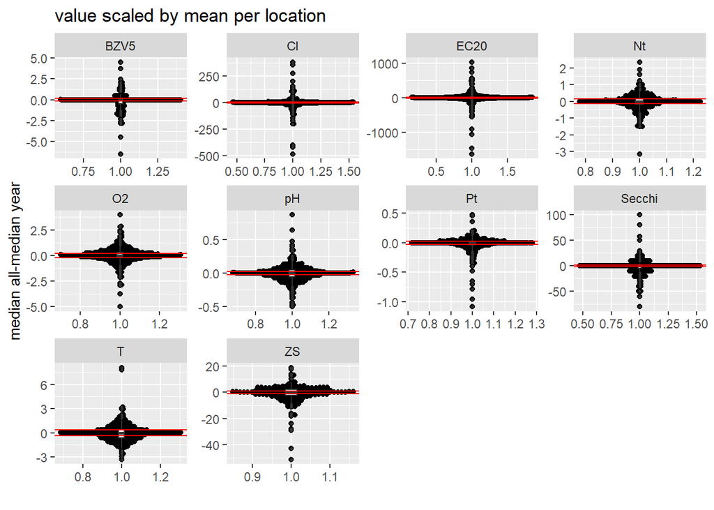

```r
ggplot(dplyr::filter(median_diff, name%in%var),aes(y=diff,x=1))+geom_beeswarm()+
  geom_boxplot(width=0.03, size=0.5)+
  geom_hline(aes(yintercept=thresh),col="red")+
  geom_hline(aes(yintercept=-thresh),col="red")+
  facet_wrap(~name,scales="free")+ylab("median all-median year") +xlab("")+ggtitle("value scaled by mean per location")
```

## Aantal waarnemingen per variabelen

```r
table(median_diff$name)
```

```
##
##    BZV5      Ca      Cl Clfyl.a    EC20      Nt      O2    oPO4      pH      Pt
##     175      55     255      40     446     261     446       2     446     259
##  Secchi       T      ZS
##     212     446     236
```

# Voer equivalence test uit en doe een p-waarde correctie

```r
p_values <- data.frame()


for(i in 1:length(var)){

test_data <- median_diff%>%
  dplyr::filter(name==var[i])

value=thresh$thresh[thresh$name==var[i]]

threshold=c(-value,value)

tost <- wilcox_TOST(x=test_data$diff,
       hypothesis = "EQU",
       eqb = threshold)

p_values <- rbind(p_values,data.frame(variable=var[i],thresh=value,statistic=tost$TOST$statistic,p_value=tost$TOST$p.value,test=row.names(tost$TOST)))

}

p_values$p_value_cor <- p.adjust(p_values$p_value,method = "fdr")
p_values$sign <- ifelse(p_values$p_value_cor<=0.05,TRUE, FALSE)

write.table(p_values, file=here("data","intermediate","equivalence_test_results.txt"),row.names=F)

p_values
```

```
##    variable      thresh statistic      p_value       test  p_value_cor  sign
## 1        Cl  3.16082299   13566.0 4.066036e-01       NHST 4.517818e-01 FALSE
## 2        Cl  3.16082299   20292.0 3.775166e-04 TOST Lower 6.662058e-04  TRUE
## 3        Cl  3.16082299   10350.0 2.057582e-07 TOST Upper 4.748266e-07  TRUE
## 4        Nt  0.14458286   13255.5 8.009604e-01       NHST 8.009604e-01 FALSE
## 5        Nt  0.14458286   24099.0 4.796666e-09 TOST Lower 1.308182e-08  TRUE
## 6        Nt  0.14458286    8875.0 8.202659e-12 TOST Upper 3.515425e-11  TRUE
## 7        O2  0.20646196   45543.5 5.909042e-01       NHST 6.331116e-01 FALSE
## 8        O2  0.20646196   73132.0 6.058625e-18 TOST Lower 9.087938e-17  TRUE
## 9        O2  0.20646196   28353.0 1.517828e-15 TOST Upper 1.517828e-14  TRUE
## 10     BZV5  0.18566075    1656.0 1.409807e-02       NHST 2.114710e-02  TRUE
## 11     BZV5  0.18566075    8886.0 3.697766e-02 TOST Lower 5.282522e-02 FALSE
## 12     BZV5  0.18566075    3655.0 5.430105e-10 TOST Upper 1.629031e-09  TRUE
## 13     EC20 14.02206321   46349.0 7.960449e-01       NHST 8.009604e-01 FALSE
## 14     EC20 14.02206321   69209.0 5.747399e-13 TOST Lower 2.873700e-12  TRUE
```

[output cut: 16 more lines]

De TOST functie doet eigenlijk 3 testen. 1 NHST test: null hypothese = het verschil in medianen is gelijk aan 0 alternatieve hypothese = verschil is groter dan 0 => we willen dat deze test niet significant is 2 TOST Lower: null hypothese = het verschil in medianen is kleiner dan de treshold alternatieve hypothese = verschil is groter dan de threshold => dit willen we significant zien

3 TOST Uper: null hypothese = het verschil in medianen is groter dan de treshold alternatieve hypothese = verschil is kleiner dan de threshold => dit willen we ook significant zien

Enkel voor BZV5 is de test niet significant, dus hiervan kunnen we niet zeggen dat de medianen gelijk zijn aan nul. Deze variabele gebruiken we niet in de analyse.